# Assignment 1

Zhong Qihui

2018.05.11

# Assignment 1

## Reading and processing the data

To analyze our data, first we should read the data.

```r
activity <- read.csv('activity.csv')
```

## Plotting the histogram

So now we can draw the histogram with the processed dataset.

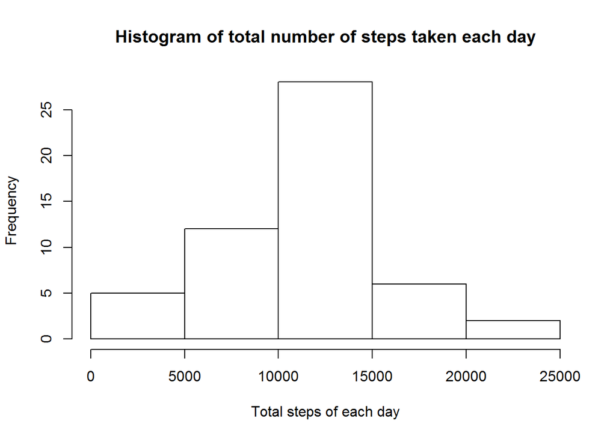

```r
hist(with(activity,tapply(steps,date,sum)),xlab='Total steps of each day', main='Histogram of total number of steps taken each day')
```

We can conclude from the histogram that total numbers of total steps taken for more than 25 days fall between 10000 and 15000.

## Descriptive summary

Then let’s take a look at the mean and median number of steps taken each day.

```r
summary(with(activity,tapply(steps,date,sum)))
```

```
##    Min. 1st Qu.  Median    Mean 3rd Qu.    Max.    NA's
##      41    8841   10765   10766   13294   21194       8
```

From the result, we can know that the average and median numbers of steps taken each day are 10,766 and 10,765 respectively.

# Creating datetime variable

```r
sec <- activity$interval * 36
day <- as.POSIXct(activity$date,tz='GMT')
datetime <- day+sec
```

# Making the time series plot

With the new datetime variable, we can plot now.

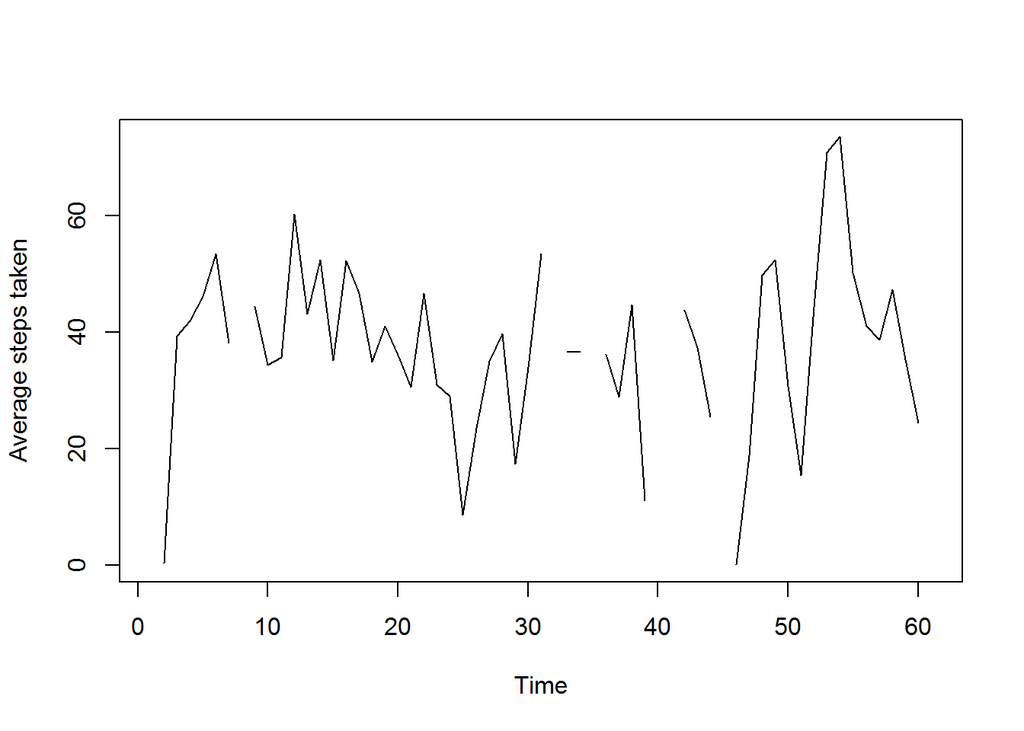

```r
plot(tapply(activity$steps,as.Date(datetime),mean),type='l',xlab='Time',ylab='Average steps taken')
```

From the above graph, we can easily find that there are missing values. They may affect our decisions. Therefore, we should exclude these missing values.

## Finding the specific interval

We need to find out the specific interval during which has the most steps taken.

```r
datetime[grep(max(activity$steps,na.rm=TRUE),activity$steps)]
```

```
## [1] "2012-11-27 06:09:00 GMT"
```

As we can see from the raw data, there are missing values in the steps column. We should exclude the missing values so that we can continue with our research.

```r
new_activity <- na.exclude(activity)
head(new_activity)
```

```
##     steps       date interval
## 289     0 2012-10-02        0
## 290     0 2012-10-02        5
## 291     0 2012-10-02       10
## 292     0 2012-10-02       15
## 293     0 2012-10-02       20
## 294     0 2012-10-02       25
```

Now we can see the data is clean now.

## Plotting the new histogram

With the new clean data, we can make a new histogram.

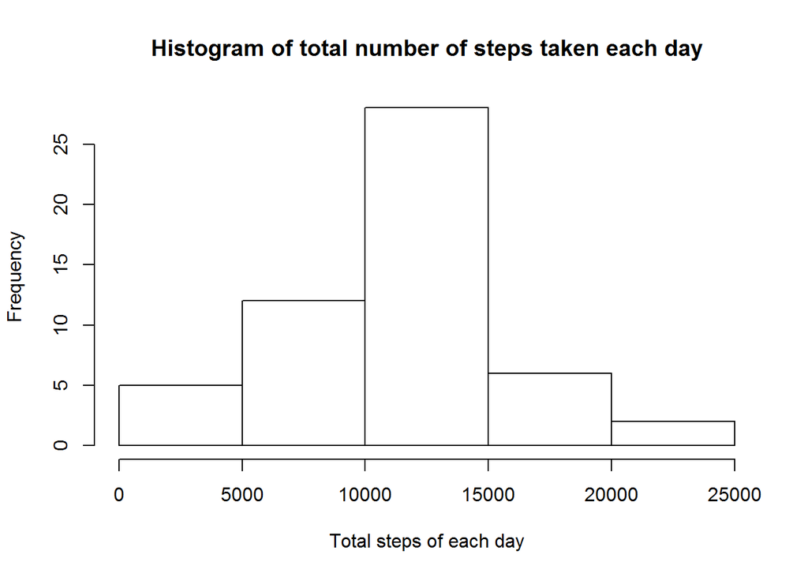

```r
hist(with(new_activity,tapply(steps,date,sum)),xlab='Total steps of each day', main='Histogram of total number of steps taken each day')
```

The new graph should look the same as the old one because missing values would not affect total number.

## Making the panel plot

### Grouping weekdays and weekends

Before plotting, we should figure out an important thing: which days are weekdays/weekends? It would be good if we define a new variable to group the dates. I come from China, so I need to set the locale first.

```r
Sys.setlocale(category = "LC_ALL", locale = "US")
```

```
## [1] "LC_COLLATE=English_United States.1252;LC_CTYPE=English_United States.1252;LC_MONETARY=English_United States.1252;LC_NUMERIC=C;LC_TIME=English_United States.1252"
```

```r
sec1 <- new_activity$interval * 36
day1 <- as.POSIXct(new_activity$date,tz='GMT')
datetime1 <- day1+sec1
wkd <- weekdays(datetime1)
wkd1 <- wkd
wkd1[wkd1 == 'Monday'] <- 1
wkd1[wkd1 == 'Tuesday'] <- 1
wkd1[wkd1 == 'Wednesday'] <- 1
wkd1[wkd1 == 'Thursday'] <- 1
wkd1[wkd1 == 'Friday'] <- 1
wkd1[wkd1 == 'Saturday'] <- 2
wkd1[wkd1 == 'Sunday'] <- 2
wkd2 <- factor(wkd1,c(1,2),labels=c('Weekday','Weekend'))
new_activity <- transform(new_activity,wkd=wkd2)
na1 <- subset(new_activity,wkd=='Weekday')
na2 <- subset(new_activity,wkd=='Weekend')
```

### Panel plot

Now I have added the new variable to the data frame. I can plot now.

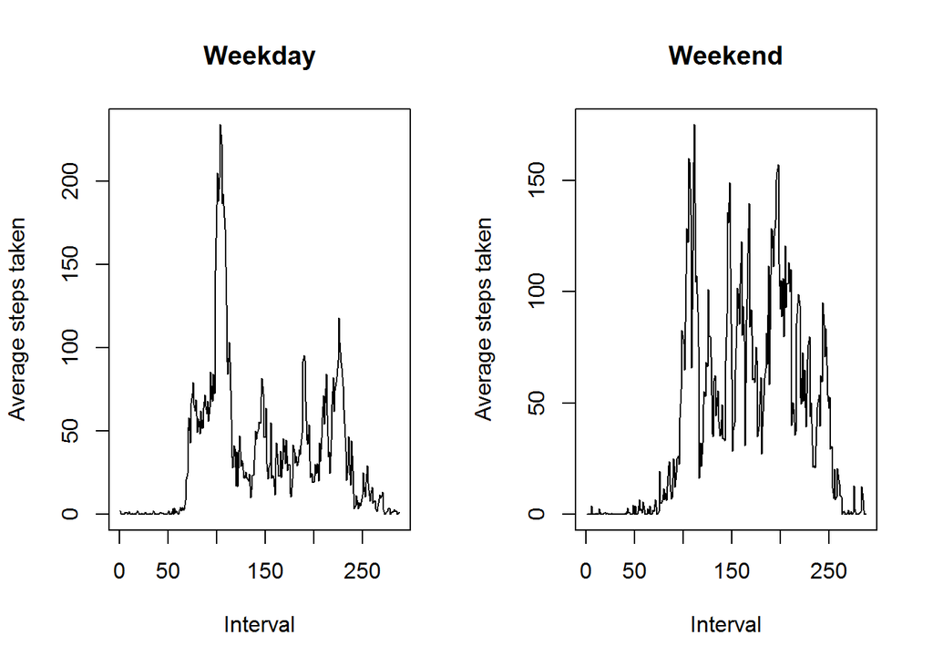

```r
par(mfrow=c(1,2))
with(na1,plot(tapply(steps,interval,mean),type='l',xlab='Interval',
     ylab='Average steps taken'))
title('Weekday')
with(na2,plot(tapply(steps,interval,mean),type='l',xlab='Interval',
     ylab='Average steps taken'))
title('Weekend')
```

From the panel plot, we can see people take more steps on weekends.